# OpenCyto TutorialRobust and Reproducible Automated Gating of Cytometry DataBioC 2014

July, 2014

## What is OpenCyto?

**Not an algorithm, but a *framework* for automated gating.**

**Goals**

- Easily build *reproducible gating pipelines*.
- *Use any gating algorithm*
  - interchange any algorithm at any step (support gating plugins)
- Simplify data handling and data management.
  - Easily pass subsets of the data (cell subsets) to different gating algorithms.
- Simple(r) pipeline template definitions
  - Pipeline defined via text file (csv)
  - Templates and code are *re-usable* for standardized assays and data.
- Facilitate comparative analysis
  - Import manually gated data from FlowJo workspaces
- Scale to *large* data sets
  - HDF5 support - data sets limited by disk space not RAM.

## Overview

Raw data ➙ Preprocessing ➙ Annotation ➙ Gating ➙ Statistical analysis ➙ Output

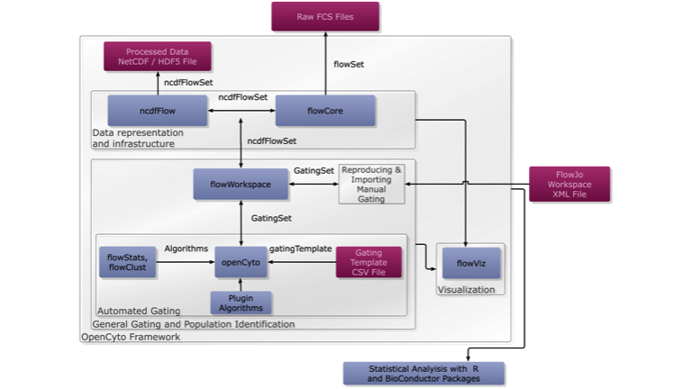

## Getting Started

### Installation

**Requirements: R + Bioconductor**

- Install *release version* of R from [CRAN](http://cran.r-project.org/).
- Install *release version* of BioConductor from [bioconductor.org/install](http://www.bioconductor.org/install/)
- Install OpenCyto and its dependencies
  - Within R type the following:

```r
require(BiocInstaller)
biocLite("openCyto")
```

This installs all the required packages.

Still have problems? [Bioconductor mailing list](https://stat.ethz.ch/mailman/listinfo/bioconductor)  
Email: Mike Jiang or Greg Finak  
Twitter: [@OpenCyto](http://www.twitter.com/OpenCyto)

## Getting Started II

*Alternately* if you are brave and want the latest bug fixes and features - *github.com/RGLab*

```r
require(devtools)
packages<-c("RGLab/flowStats","RGLab/flowCore","RGLab/flowViz","RGLab/ncdfFlow","RGLab/flowWorkspace","RGLab/openCyto")
install_github(packages,quick=TRUE)
```

You may use the *devtools* package to install the latest stable versions directly from github.

## A Worked Example

### Intracellular Cytokine Staining of Antigen-stimulated T-cells

- Full data set at Flowrepository.org [FR-FCM-ZZ7U](http://flowrepository.org/experiments/254/public_id)
- Batch 0882, 76 sample files, 13 compensation controls.

```r
ws<-openWorkspace("data/workspace/080 batch 0882.xml")
```

```
FlowJo Workspace Version  2.0
File location:  data/workspace
File name:  080 batch 0882.xml
Workspace is open.
Groups in Workspace
          Name Num.Samples
1  All Samples         158
2   0882-L-080         157
3        Comps          13
4 0882 Samples          76
```

## Import Manual Gating (parseWorkspace)

Create a gating set of manual gates.

```r
gating_set<-parseWorkspace(ws,name="0882 Samples",path="data/FCS/",isNcdf=TRUE)
```

[output not shown]

```
Parsing 76 samples
calling c++ parser...
...
```

We now have gated, compensated and transformed data in an *HDF5* file represented in a *GatingSet* object. We can save it for later use.

```r
save_gs(gating_set,path="data/manual_gating")
```

```
saving ncdf...
saving tree object...
saving R object...
Done
To reload it, use 'load_gs' function
```

The archived gating set contains all the information on transformation, compensation, single-cell events, and gates and can be *shared with collaborators*.

## Visualizing the Gating Layout (plotGate)

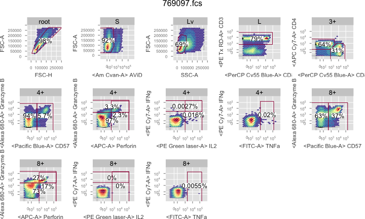

```r
plotGate(gating_set[[1]],xbin=16,gpar=list(ncol=5)) # Binning for faster plotting
```

## Visualizing the Gating Tree (plot)

Calling `plot` on the gating set gives us a view of the gating tree.

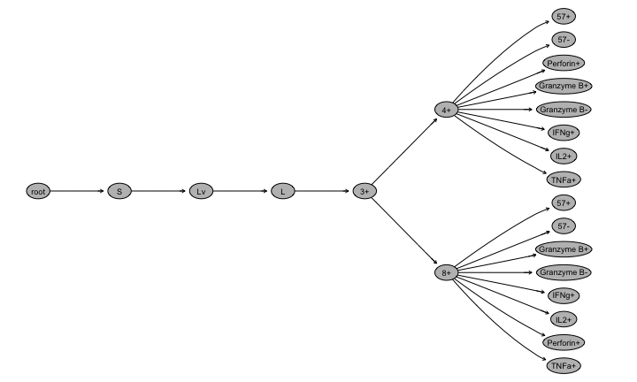

## Annotation

```r
keyword_vars<-c("$FIL","Stim","Sample Order","EXPERIMENT NAME") #relevant keywords
pd<-data.table(getKeywords(gating_set,keyword_vars)) #extract relevant keywords to a data table
annotations<-data.table:::fread("data/workspace/pd_submit.csv") # read the annotations from flowrepository
pd<-data.frame(annotations[pd]) #data.table style merge
setnames(pd,c("Timepoint","Individual"),c("VISITNO","PTID"))
pData(gating_set)<-pd #annotate
```

| name | Condition | VISITNO | PTID | Sample.Description |
| --- | --- | --- | --- | --- |
| 769121.fcs | negctrl | 5 | 080-17 | PBMCs from healthy subjects |
| 769122.fcs | negctrl | 5 | 080-17 | PBMCs from healthy subjects |
| 769193.fcs | GAG-1-PTEG | 5 | 080-17 | PBMCs from healthy subjects |
| 769225.fcs | POL-1-PTEG | 5 | 080-17 | PBMCs from healthy subjects |

## Clone and save for automated gating

We want to perform automated gating of this data.

- We'll clone the gating set, delete existing nodes and re-save the data as a new gating set.

```r
auto_gating<-clone(gating_subset)
Rm("S",auto_gating)
save_gs(auto_gating,path="data/autogating",overwrite=TRUE)
```

```r
list.files("data/autogating")
```

```
## [1] "file9e8620253f4.nc" "NHxz3bpHGl.dat"     "NHxz3bpHGl.rds"
```

- `.nc` file is the HDF5 file of event-level data..
- `.dat` file contains the gating set representation from the `C` data structure.
- `.rds` file is an `R` data file that contains the R-object information.

Send it to a friend, `load_gs()` will read it all in and the data will be available.

## Costructing a Template - I

| alias | pop | parent | dims | gating_method | gating_args | groupBy | preprocessing_method |
| --- | --- | --- | --- | --- | --- | --- | --- |
| boundary | boundary | root | FSC-A,SSC-A | boundary | max=c(2.5e5,2.5e5) |  |  |
| singlet | singlet | boundary | FSC-A,FSC-H | singletGate | prediction_level=0.999,wider_gate=TRUE,subsample_pct=0.2 |  |  |
| viable | viable- | singlet | AViD | mindensity | gate_range=c(500,1000) |  |  |
| nonNeutro | nonNeutro- | viable | SSC-A | mindensity | gate_range=c(5e4,1.5e5) |  |  |
| DebrisGate | DebrisGate+ | nonNeutro | FSC-A | mindensity | gate_range=c(0,1e+05) |  |  |
| nonDebris | nonDebris+ | viable | FSC-A | refGate | DebrisGate |  |  |
| lymph | lymph | nonDebris | FSC-A,SSC-A | flowClust | K=2,quantile=0.99 |  | prior_flowClust |
| cd3 | cd3+ | lymph | cd3 | mindensity |  |  |  |

## Costructing a Template - II

Each row defines a cell population

- `alias`: how we refer to the population / shorthand
- `pop`: The population definition i.e. do we keep the positive (+) or negative (-) cells for a marker / pair of markers after gating.
- `parent`: The alias of the parent population on which the current population is defined
- `dims`: The dimensions / markers used to define this cell population.
- `gating_method`: Which gating algorithm to use.
- `gating_args`: additional arguments passed to the gating method to tweak various parameters
- `collaseDataForGating`: TRUE or FALSE. Together with groupBy will gate multiple samples with a common gate.
- `groupBy`: Specify metadata variables for combining samples (e.g. PTID)
- `preprocessing_method`: advanced use for some gating methods
- `preprocessing_args`: additional arguments

## Constructing a Template - III

We read in the template and visualize it

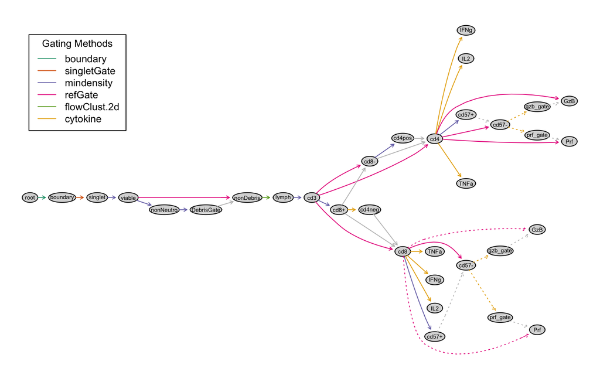

```r
gt<-gatingTemplate("data/template/gt_080.csv")
plot(gt)
```

## Automated Gating

openCyto walks through the template and gates each population in each sample using the algoirthm named in the template.

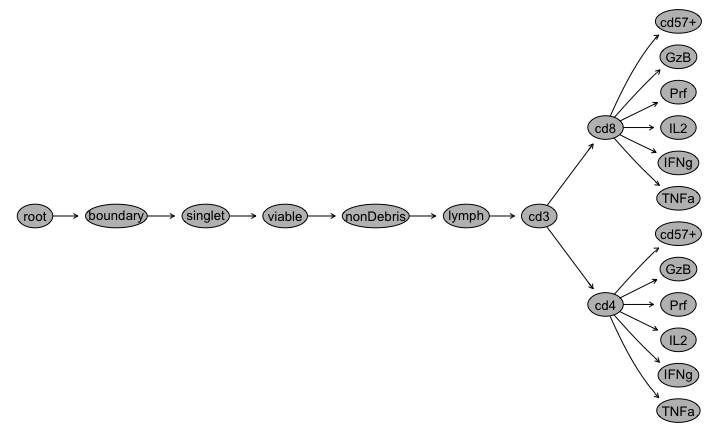

```r
gating(x = gt, y =  auto_gating)
## Some output..
plot(auto_gating)
```

## Automated Gating - II

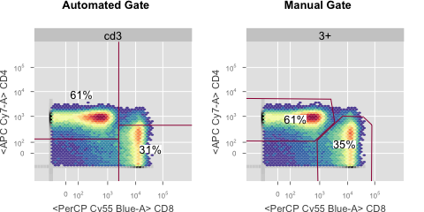

```r
p1<-plotGate(auto_gating[[1]],c("cd8","cd4"),arrange=FALSE,
             projections=list("cd4"=c(x="CD8",y="CD4"),"cd8"=c(x="CD8",y="CD4")),
             main="Automated Gate",path=2)[[1]]
p2<-plotGate(gating_subset[[1]],c("8+","4+"),
             projections=list("4+"=c(x="CD8",y="CD4"),"8+"=c(x="CD8",y="CD4")),
             arrange=FALSE,main="Manual Gate",path=2)[[1]]

grid.arrange(arrangeGrob(p1,p2,ncol=2))
```

Stats and gates are comparable, could be tweaked if necessary, but importantly it's reproducible. Always generate the same result.

## Extract Stats and Compare Manual to Automated

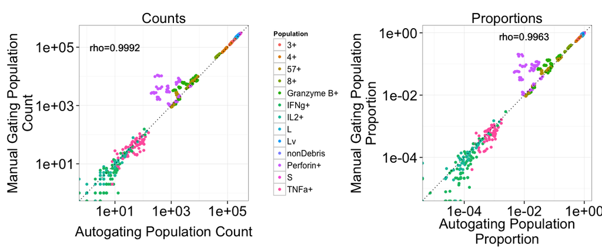

```r
#Extract stats
auto_stats<-getPopStats(auto_gating,statistic="count")
manual_stats<-getPopStats(gating_subset,statistic="count")
```

Note Perforin is incorrectly gated in the manual analysis. Minor differences at low end, but reproducible and objective.

## Perforin - Cytokine gate and reference gate

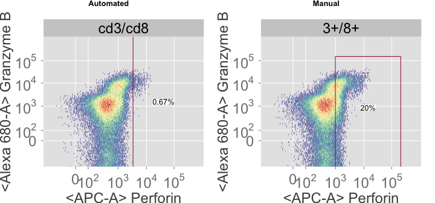

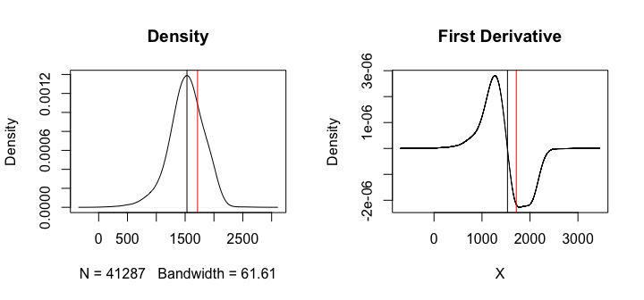

Automated gate set on CD57- (reference). Perforin-negative cells included in the manual gate.

## TNFa

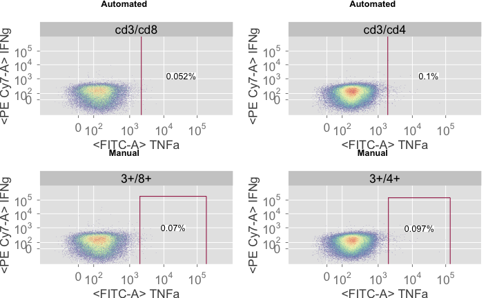

## Some Useful Functions

Return a `flowSet` containing event-level data for the named cell population.

```r
cd3_population<-getData(auto_gating,"cd3")
```

Plot a named cell population.

```r
plotGate(auto_gating,"cd3")
```

Subset by FCS file(s).

```r
first_ten_fcs_files<-auto_gating[1:10]
```

List supported gating methods (that can be used in a template).

```r
listgtMethods()
```

Register a new gating or preprocessing plugin.

```r
registerPlugins(myfunction,methodName,dependencies, "preprocessing"|"gating")
```

## Some More Useful Functions

Generate a Basic GatingTemplate from a Manual Gating Hierarchy.

```r
templateGen(gating_subset[[1]])
```

| alias | pop | parent | dims | gating_method | gating_args | collapseDataForGating | groupBy | preprocessing_method | preprocessing_args |
| --- | --- | --- | --- | --- | --- | --- | --- | --- | --- |
| S | S | root | FSC-H,FSC-A |  |  |  |  |  |  |
| Lv | Lv | /S | ,FSC-A |  |  |  |  |  |  |
| L | L | /S/Lv | SSC-A,FSC-A |  |  |  |  |  |  |
| 3+ | 3+ | /S/Lv/L | , |  |  |  |  |  |  |
| 8+ | 8+ | /S/Lv/L/3+ | , |  |  |  |  |  |  |
| TNFa+ | TNFa+ | /S/Lv/L/3+/8+ | , |  |  |  |  |  |  |
| Perforin+ | Perforin+ | /S/Lv/L/3+/8+ | , |  |  |  |  |  |  |

Just fill in the `gating_method` and `dims` to get started.

## Your turn

Under `/data/OpenCyto` you'll find the data and some R code to reproduce the analysis in these slides. Begin there.

- Copy the code to your home directory and work from there.
- Paths are set up to write to your home directory.
- Load the workspace and reproduce the manual gating.
- Clone the gating set and clear the manual gates.
- Load the template and run the automated gating.

## Gating Method Examples - mindensity

Infers a gate threshold based on the minimum density separating two major populations in a 1-D density estimate.

- Open the `csv` template in a new window, the definition for the live/dead gate is:

`viable, viable-, singlet, AViD, mindensity, gate_range=c(500,1000)`  
`gate_range` restricts the data region where the method searches for a cutpoint.  
`adjust` alters the smoothing (larger value = more smoothing, less *bumpy*)

- Play with these parameters in the gating template.
  - What happens if you remove the `gate_range` parameter?
  - What happens if you set `adjust=0.75`?

```r
# Work with a subset of the data
auto_subset<-auto_gating[1:20] # first 20 samples
# Make changes in the template. SAVE it, then re-load it in R.
gt<-gatingTemplate("data/template/gt_080.csv")
# Remove the old gate from auto_gating
Rm("viable",auto_subset)
# Gate with the new template, stop after the viable gate (which is nonNeutro)
gating(gt,auto_subset,stop.at="nonNeutro")
# View the new result
plotGate(auto_subset,"viable")
```

## Where we've used OpenCyto

Studies wtih 100s of GB of data.  
None take more than a couple of hours to run.

- Gating of Lyoplate standardized staining panels (FlowCAP III)
- Many large clinical trial ICS data sets at the HVTN
- ICS data - MTB infected vs. healthy subjects.
- CyTOF combinatorial cytokine data
  - Exhaustive gating of polyfunctional T-cell subsets.

Event-level data and cell population memberships can easily be shared with collaborators.

Quickly pushed to downstream analysis. * MIMOSA (PMC3862207) * COMPASS (http://rglab.github.org/COMPASS/)

We're usually pretty friendly and can help you get started

## Summary

- A framework for standardizing analysis pipelines.
- Flexible support of different gating approaches via plugins
  - e.g flowDensity is supported.
- Re-usable templates and code
  - Work is done up front for set up.
  - Fully reproducible and *objective, data-driven gating*.
- OpenCyto simplifies
  - Data import (raw data and/or manual gating from FlowJo workspace)
  - Preprocessing
  - Data manipulation (interacting with cell subsets)
  - Plotting and visualization
  - Extracting statistics for reports
  - Downstream analysis with the full power of R's tools.

## Online Resources

- OpenCyto website: http://opencyto.org
  - Documentation
  - Reproducible examples and data
- Our Github repository: http://github.org/RGLab/OpenCyto
- These slides: http://gfinak.github.io/OpenCytoTutorial
  - Code: http://www.github.com/gfinak/OpenCytoTutorial
- The BioConductor website: http://www.bioconductor.org

## Next steps

Time to dive in and try using the framework. - We've provided the data for this tutorial, as well as the code to generate these slides. - Step through the code.. some things are not exactly as simple as presented here. - Annotating the data appropriately can sometimes take a bit of work - People running the cytometer or using FlowJo don't always annotate their data -

## Acknowledgements

*RGLab @ Fred Hutchinson Cancer Research Center*  
**Raphael Gottardo**  
**Mike Jiang**  
**Jacob Frelinger**  
*John Ramey*

*Collaborators*  
**Steve De Rosa** @ HIV Vaccine Trials Network  
**Adam Asare** @ Immune Tolerance Network  
**Evan Newell** @ Singapore Immunology Network  
**Mark Davis** @ Stanford  
**Adam Triester** @ TreeStar Inc.  
**Jay Almarode** @ TreeStar Inc.

*Funding*  
National Institutes of Health  
Human Immune Project Consortium (HIPC)